# Case Study - 01

Eric Laigaie & Alex Lopez

10/5/2021

### Introduction: In this presentation, we will be looking at the locations of the breweries making beers, beer alcohol content, and beer international bitterness units. After reviewing the data, we will then look at how ABV and IBU can be used to identify whether or not a beer is an IPA or another type of Ale. Finally, we will dive into one other inference that we believe will help you decide what type of beer Budweiser should be producing.

```r
beers = read.csv('/Users/alexanderlopez/Documents/SMU/Classes/MSDS_6306_Doing_Data_Science/Case_Study_1/Case-Study-01/Beers.csv', header = TRUE)
breweries = read.csv('/Users/alexanderlopez/Documents/SMU/Classes/MSDS_6306_Doing_Data_Science/Case_Study_1/Case-Study-01/Breweries.csv', header = TRUE)
```

1. How many breweries are present in each state?

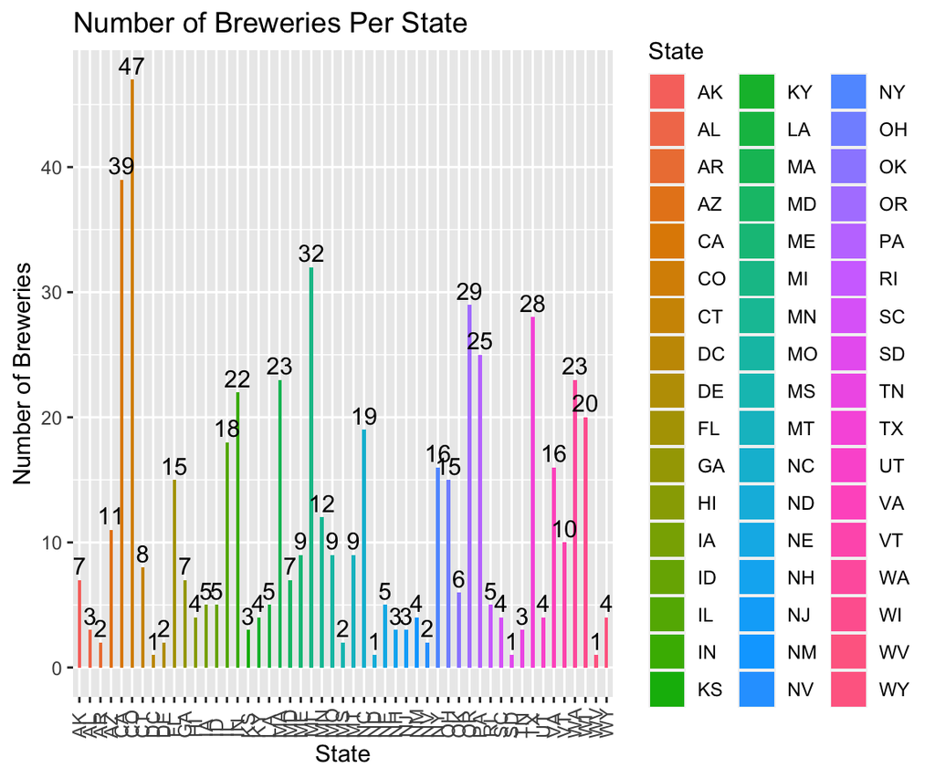

```r
# Creating a bar plot to visualize brewery count by state
breweries %>% group_by(State) %>% ggplot(aes(x=State, fill = State)) + geom_bar(width = .33) + theme(axis.text.x = element_text(angle = 90, vjust = 0.5, hjust=.1), aspect.ratio=6/5) + geom_text(stat='count', aes(label=..count..), vjust=-.33) + labs(title = 'Number of Breweries Per State', y = 'Number of Breweries')
```

2. Merge beer data with the breweries data. Print the first 6 observations and the last six observations to check the merged file. (RMD only, this does not need to be included in the presentation or the deck.)

```r
# First, review the data sets
summary(beers)
```

```
##      Name              Beer_ID            ABV               IBU
##  Length:2410        Min.   :   1.0   Min.   :0.00100   Min.   :  4.00
##  Class :character   1st Qu.: 808.2   1st Qu.:0.05000   1st Qu.: 21.00
##  Mode  :character   Median :1453.5   Median :0.05600   Median : 35.00
##                     Mean   :1431.1   Mean   :0.05977   Mean   : 42.71
##                     3rd Qu.:2075.8   3rd Qu.:0.06700   3rd Qu.: 64.00
##                     Max.   :2692.0   Max.   :0.12800   Max.   :138.00
##                                      NA's   :62        NA's   :1005
##    Brewery_id       Style               Ounces
##  Min.   :  1.0   Length:2410        Min.   : 8.40
##  1st Qu.: 94.0   Class :character   1st Qu.:12.00
##  Median :206.0   Mode  :character   Median :12.00
##  Mean   :232.7                      Mean   :13.59
##  3rd Qu.:367.0                      3rd Qu.:16.00
##  Max.   :558.0                      Max.   :32.00
##
```

```r
summary(breweries)
```

```
##     Brew_ID          Name               City              State
##  Min.   :  1.0   Length:558         Length:558         Length:558
##  1st Qu.:140.2   Class :character   Class :character   Class :character
##  Median :279.5   Mode  :character   Mode  :character   Mode  :character
##  Mean   :279.5
##  3rd Qu.:418.8
##  Max.   :558.0
```

```r
# Merge needs to be done on the Brew_ID column
# Need to first make brewery id column names the same
names(beers)[5] = 'Brew_ID'
df = merge(beers,breweries,"Brew_ID",suffixes = c('_Beers','_Brewery'))

# Printing head (first 6) and tail (last 6) observations
head(df,6)
```

```
##   Brew_ID    Name_Beers Beer_ID   ABV IBU                               Style
## 1       1  Get Together    2692 0.045  50                        American IPA
## 2       1 Maggie's Leap    2691 0.049  26                  Milk / Sweet Stout
## 3       1    Wall's End    2690 0.048  19                   English Brown Ale
## 4       1       Pumpion    2689 0.060  38                         Pumpkin Ale
## 5       1    Stronghold    2688 0.060  25                     American Porter
## 6       1   Parapet ESB    2687 0.056  47 Extra Special / Strong Bitter (ESB)
##   Ounces      Name_Brewery        City State
## 1     16 NorthGate Brewing Minneapolis    MN
## 2     16 NorthGate Brewing Minneapolis    MN
## 3     16 NorthGate Brewing Minneapolis    MN
## 4     16 NorthGate Brewing Minneapolis    MN
## 5     16 NorthGate Brewing Minneapolis    MN
## 6     16 NorthGate Brewing Minneapolis    MN
```

```r
tail(df,6)
```

```
##      Brew_ID                Name_Beers Beer_ID   ABV IBU
## 2405     556             Pilsner Ukiah      98 0.055  NA
## 2406     557  Heinnieweisse Weissebier      52 0.049  NA
## 2407     557           Snapperhead IPA      51 0.068  NA
## 2408     557         Moo Thunder Stout      50 0.049  NA
## 2409     557         Porkslap Pale Ale      49 0.043  NA
## 2410     558 Urban Wilderness Pale Ale      30 0.049  NA
##                        Style Ounces                  Name_Brewery          City
## 2405         German Pilsener     12         Ukiah Brewing Company         Ukiah
## 2406              Hefeweizen     12       Butternuts Beer and Ale Garrattsville
## 2407            American IPA     12       Butternuts Beer and Ale Garrattsville
## 2408      Milk / Sweet Stout     12       Butternuts Beer and Ale Garrattsville
## 2409 American Pale Ale (APA)     12       Butternuts Beer and Ale Garrattsville
## 2410        English Pale Ale     12 Sleeping Lady Brewing Company     Anchorage
##      State
## 2405    CA
## 2406    NY
## 2407    NY
## 2408    NY
## 2409    NY
## 2410    AK
```

3. Address the missing values in each column.

```r
# There are missing values in both ABV (alcohol by volume) and IBU (international bitterness unit)
# 62 NA values for ABV (62/2410 = 3%)
# 1005 NA values for IBU (1005/2410 = 42%)
# Quick web search indicates that beers can have 0 ABV and IBU
# Assume NA values equal to 0 to avoid removing approx. 40% of data
# Change Na's to 0
df$ABV[is.na(df$ABV)] = 0
df$IBU[is.na(df$IBU)] = 0

# Final check reveals there are 5 NA char values in Style Column
# Since there are only 5 NA values (5/2410 = 0.2%), observations will be dropped
sum(is.na(df))
```

```
## [1] 5
```

```r
sum(is.na(df$Style))
```

```
## [1] 5
```

```r
# Dropping remaining NA values
df = na.omit(df)
```

4. Compute the median alcohol content and international bitterness unit for each state. Plot a bar chart to compare.

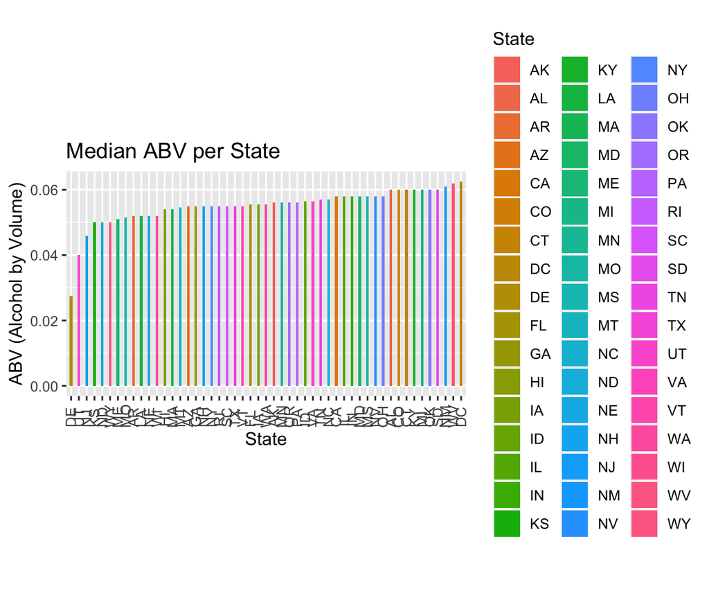

```r
# Group_by State and then plot the medians of ABV and IBU.

df %>% group_by(State) %>% dplyr::summarize(med_abv = median(ABV)) %>% ggplot(aes(x=reorder(State, med_abv),y=med_abv,fill=State)) + geom_bar(stat="identity",width = .33) + theme(axis.text.x = element_text(angle = 90, vjust = 0.5, hjust=.1), aspect.ratio=9/16) + labs(title = 'Median ABV per State',x='State', y = 'ABV (Alcohol by Volume)')
```

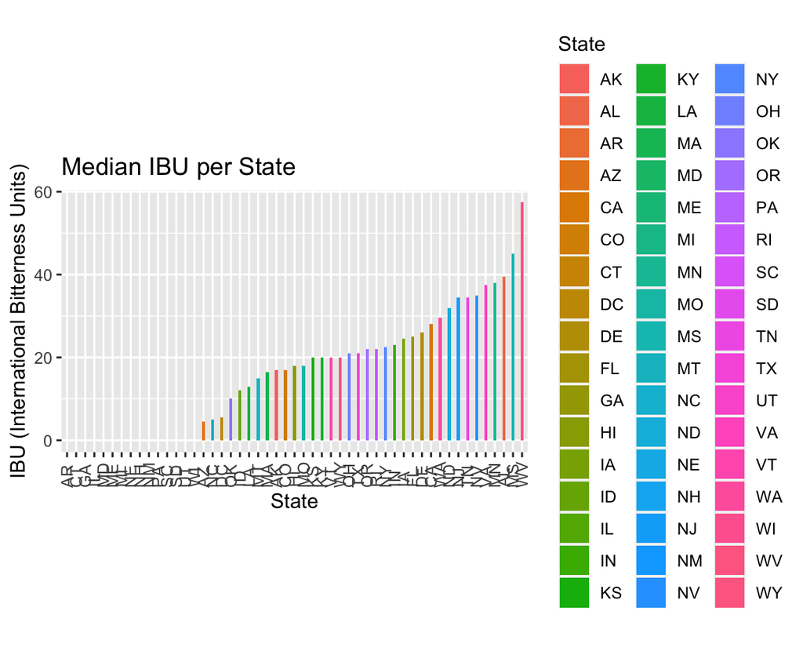

```r
df %>% group_by(State) %>% dplyr::summarize(med_ibu = median(IBU)) %>% ggplot(aes(x=reorder(State, med_ibu),y=med_ibu,fill=State)) + geom_bar(stat="identity",width = .33) + theme(axis.text.x = element_text(angle = 90, vjust = 0.5, hjust=.1), aspect.ratio=9/16) + labs(title = 'Median IBU per State',x='State', y = 'IBU (International Bitterness Units)')
```

```r
# Since there were so many Beers with 0 IBU, the mean may give better insight(?)
```

5. Which state has the maximum alcoholic (ABV) beer? Which state has the most bitter (IBU) beer? Ans. The state with the highest alcohol by volume beer is Colorado. The state with the most bitter beer is Oregon.

```r
# Function which.max will give max value for specified column.

df[which.max(df$ABV),] # Beer_ID = 2565
```

```
##     Brew_ID                                           Name_Beers Beer_ID   ABV
## 375      52 Lee Hill Series Vol. 5 - Belgian Style Quadrupel Ale    2565 0.128
##     IBU            Style Ounces            Name_Brewery    City State
## 375   0 Quadrupel (Quad)   19.2 Upslope Brewing Company Boulder    CO
```

```r
df[which.max(df$IBU),] # Beer_ID = 980
```

```
##      Brew_ID                Name_Beers Beer_ID   ABV IBU
## 1857     375 Bitter Bitch Imperial IPA     980 0.082 138
##                               Style Ounces            Name_Brewery    City
## 1857 American Double / Imperial IPA     12 Astoria Brewing Company Astoria
##      State
## 1857    OR
```

6. Comment on the summary statistics and distribution of the ABV variable. Ans. The summary stats would indicate a semi-normal distribution seeing that the mean and medium are fairly similar. The histograms and box plots also show signs of a normal distribution but with a right (positive) skew. The histogram appears more “normal” once the non-alcoholic beers are filtered out of the data set.

```r
# First, review the 5 number summary and std values for ABV.

summary(df$ABV)
```

```
##    Min. 1st Qu.  Median    Mean 3rd Qu.    Max.
## 0.00000 0.05000 0.05600 0.05831 0.06700 0.12800
```

```r
sd(df$ABV)
```

```
## [1] 0.01626515
```

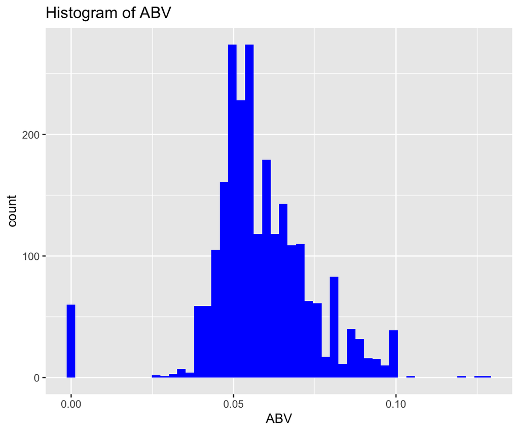

```r
# Histograms
df %>% ggplot(aes(x=ABV)) + geom_histogram(bins = 50,fill='blue') + labs(title = 'Histogram of ABV')
```

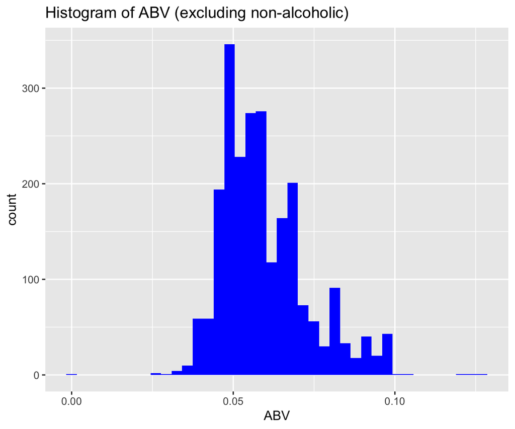

```r
# Non-alcoholic beers appear to be negative outliers and should be removed if we are to analyze beer ABV.

df %>% filter(ABV>0) %>% ggplot(aes(x=ABV)) + geom_histogram(bins = 40,fill='blue') + labs(title = 'Histogram of ABV (excluding non-alcoholic)')
```

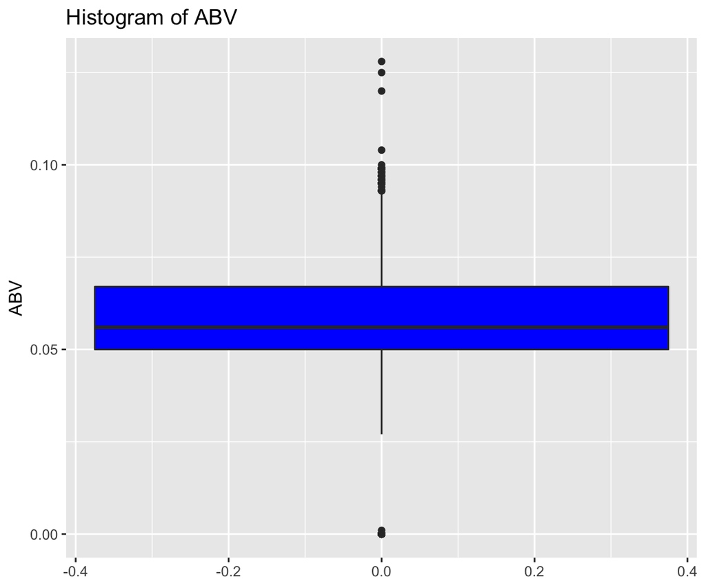

```r
# Box Plots
df %>%  ggplot(aes(y=ABV)) + geom_boxplot(fill='blue') + labs(title = 'Histogram of ABV')
```

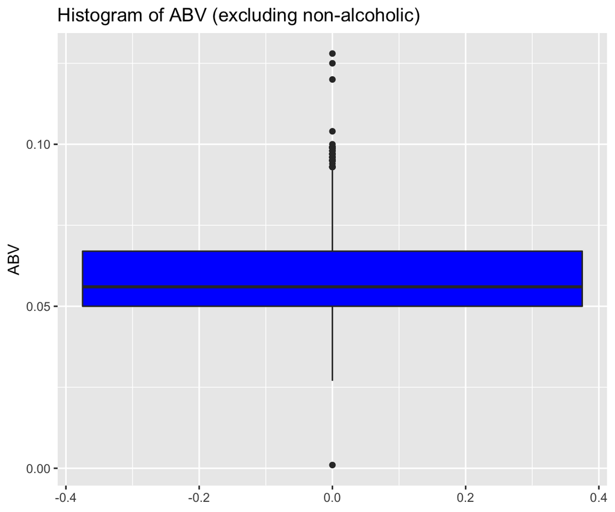

```r
df %>% filter(ABV>0) %>% ggplot(aes(y=ABV)) + geom_boxplot(fill='blue') + labs(title = 'Histogram of ABV (excluding non-alcoholic)')
```

```r
# Non-alcoholic beers do not seem as apparent in box plots.
```

7. Is there an apparent relationship between the bitterness of the beer and its alcoholic content? Draw a scatter plot. Make your best judgment of a relationship and EXPLAIN your answer. Ans. Looking at the scatter plot and smooth fit line, there is visual evidence of a positive correlation between ABV and IBU.

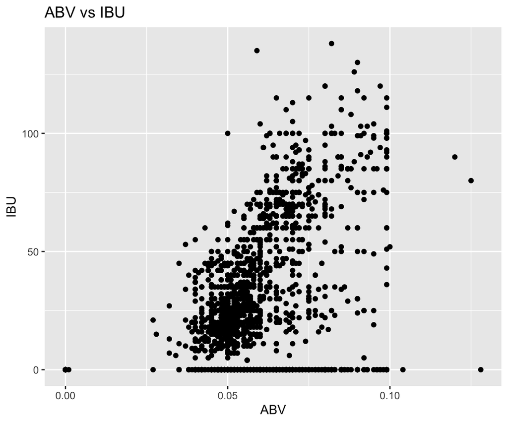

```r
# Using all data points
df %>% ggplot(aes(x=ABV,y=IBU)) + geom_point() + labs(title = 'ABV vs IBU')
```

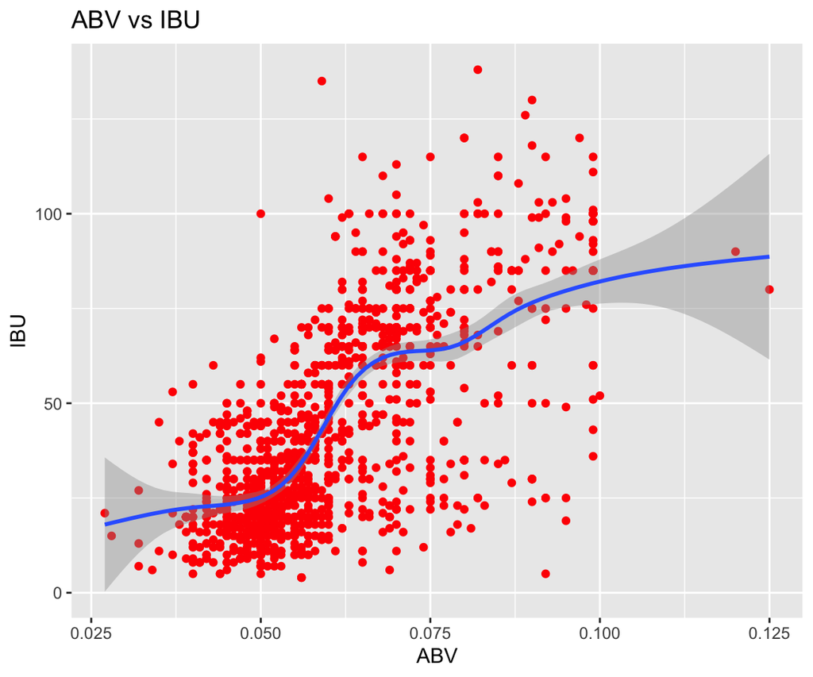

```r
# Excluding beers with IBU = 0
df %>% filter(IBU>0) %>% ggplot(aes(x=ABV,y=IBU)) + geom_point(color='red') + geom_smooth() + labs(title = 'ABV vs IBU')
```

8. Budweiser would also like to investigate the difference with respect to IBU and ABV between IPAs (India Pale Ales) and other types of Ale (any beer with “Ale” in its name other than IPA). You decide to use KNN classification to investigate this relationship. Provide statistical evidence one way or the other. You can of course assume your audience is comfortable with percentages … KNN is very easy to understand conceptually.

In addition, while you have decided to use KNN to investigate this relationship (KNN is required) you may also feel free to supplement your response to this question with any other methods or techniques you have learned. Creativity and alternative solutions are always encouraged.

9. Knock their socks off! Find one other useful inference from the data that you feel Budweiser may be able to find value in. You must convince them why it is important and back up your conviction with appropriate statistical evidence.